# Tugas Pertemuan 2 - Regresi

# Penanganan Autokorelasi

## Metode Cochrane-Orcutt

Penanganan autokorelasi dilakukan dengan metode Cochrane-Orcutt, yaitu melakukan transformasi generalized least squares (GLS) secara iteratif hingga diperoleh nilai koefisien autokorelasi (ρ) yang konvergen.

```r
#Penanganan Autokorelasi Cochrane-Orcutt
modelCO<-cochrane.orcutt(model)
modelCO
```

```
## Cochrane-orcutt estimation for first order autocorrelation
##
## Call:
## lm(formula = marketshare ~ price, data = dt)
##
##  number of interaction: 8
##  rho 0.425232
##
## Durbin-Watson statistic
## (original):    1.13582 , p-value: 9.813e-03
## (transformed): 1.95804 , p-value: 4.151e-01
##
##  coefficients:
## (Intercept)       price
##    26.72209   -24.08413
```

Hasil keluaran model setelah dilakukan penanganan adalah sebagai berikut.
$$y_i= 26.72209 - 24.08413
x_t$$
Hasil juga menunjukkan bahwa nilai DW dan p-value meningkat menjadi $1.95804 $ dan $0.415$. Nilai DW sudah berada pada rentang DU < DW < 4-DU. Hal tersebut juga didukung dengan nilai *p-value* > 0.05, artinya belum cukup bukti menyatakan bahwa sisaan terdapat autokorelasi pada taraf nyata 5%. Untuk nilai $ρ ̂$ optimum yang digunakan adalah $0.4252321$. Nilai tersebut dapat diketahui dengan *syntax* berikut.

```r
#Rho optimum
rho<- modelCO$rho
rho
```

```
## [1] 0.4252321
```

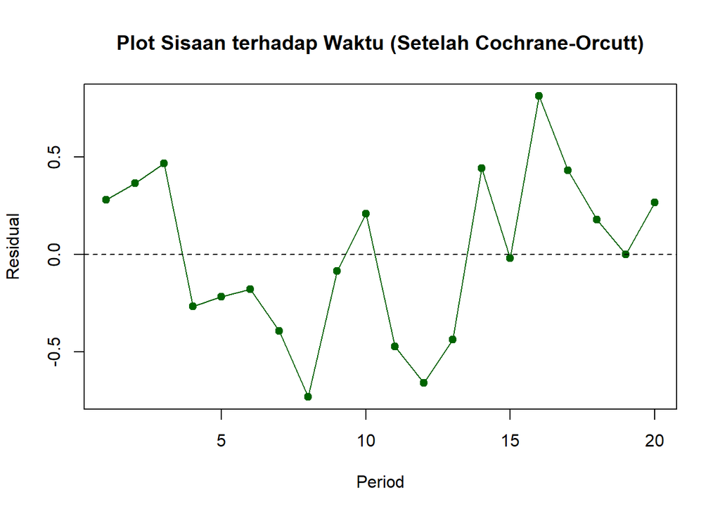

```r
sisaan.co <- dt$marketshare-(model$coefficients[1] + model$coefficients[2] * dt$price)

plot(period, sisaan.co, type = "o", pch = 19, col = "darkgreen",
     xlab = "Period", ylab = "Residual",
     main = "Plot Sisaan terhadap Waktu (Setelah Cochrane-Orcutt)")
abline(h = 0, lty = 2)
```

## Metode Hildreth-Lu

Penanganan kedua adalah menggunakan metode Hildreth-Lu. Metode ini akan mencari nilai SSE terkecil.

```r
library(HoRM)

# ambil y dan x (satu prediktor saja)
y <- dt$marketshare
x <- dt$price

# grid search rho 0–0.9
r <- seq(0, 0.9, by = 0.1)
tab <- data.frame(
  rho = r,
  SSE = sapply(r, function(rr) deviance(hildreth.lu(y, x, rr)))
)



tab            # tabel rho vs SSE
```

```
##    rho      SSE
## 1  0.0 3.212112
## 2  0.1 2.979074
## 3  0.2 2.810498
## 4  0.3 2.705239
## 5  0.4 2.661188
## 6  0.5 2.674924
## 7  0.6 2.741983
## 8  0.7 2.858804
## 9  0.8 3.026489
## 10 0.9 3.252863
```

```r
rho_hat <- tab$rho[which.min(tab$SSE)]   # rho terbaik
fit_hl  <- hildreth.lu(y, x, rho_hat)    # model final
summary(fit_hl)
```

```
##
## Call:
## lm(formula = y ~ x)
##
## Residuals:
##      Min       1Q   Median       3Q      Max
## -0.56476 -0.24781 -0.05422  0.25392  0.82998
##
## Coefficients:
##             Estimate Std. Error t value Pr(>|t|)
## (Intercept)   16.070      0.957   16.79 5.10e-12 ***
## x            -24.158      1.892  -12.77 3.88e-10 ***
## ---
## Signif. codes:  0 '***' 0.001 '**' 0.01 '*' 0.05 '.' 0.1 ' ' 1
##
## Residual standard error: 0.3957 on 17 degrees of freedom
## Multiple R-squared:  0.9055, Adjusted R-squared:    0.9
## F-statistic:   163 on 1 and 17 DF,  p-value: 3.88e-10
```

```r
#Penanganan Autokorelasi Hildreth lu
# Hildreth-Lu
hildreth.lu.func<- function(r, model){
  x <- model.matrix(model)[,-1]
  y <- model.response(model.frame(model))
  n <- length(y)
  t <- 2:n
  y <- y[t]-r*y[t-1]
  x <- x[t]-r*x[t-1]

  return(lm(y~x))
}

#Pencariab rho yang meminimumkan SSE
r <- c(seq(0.1,0.9, by= 0.1))
tab <- data.frame("rho" = r, "SSE" = sapply(r, function(i){deviance(hildreth.lu.func(i, model))}))
round(tab, 4)
```

```
##   rho    SSE
## 1 0.1 2.9791
## 2 0.2 2.8105
## 3 0.3 2.7052
## 4 0.4 2.6612
## 5 0.5 2.6749
## 6 0.6 2.7420
## 7 0.7 2.8588
## 8 0.8 3.0265
## 9 0.9 3.2529
```

Pertama-tama akan dicari di mana kira-kira $ρ$ yang menghasilkan SSE minimum. Pada hasil di atas terlihat $ρ$ minimum ketika 0.4. Namun, hasil tersebut masih kurang teliti sehingga akan dicari kembali $ρ$ yang lebih optimum dengan ketelitian yang lebih. Jika sebelumnya jarak antar $ρ$ yang dicari adalah 0.1, kali ini jarak antar $ρ$ adalah 0.001 dan dilakukan pada selang 0.3 sampai dengan 0.6.

```r
#Rho optimal di sekitar 0.4
rOpt <- seq(0.3,0.6, by= 0.001)
tabOpt <- data.frame("rho" = rOpt, "SSE" = sapply(rOpt, function(i){deviance(hildreth.lu.func(i, model))}))
head(tabOpt[order(tabOpt$SSE),])
```

```
##       rho      SSE
## 126 0.425 2.659368
## 127 0.426 2.659370
## 125 0.424 2.659372
## 128 0.427 2.659377
## 124 0.423 2.659382
## 129 0.428 2.659390
```

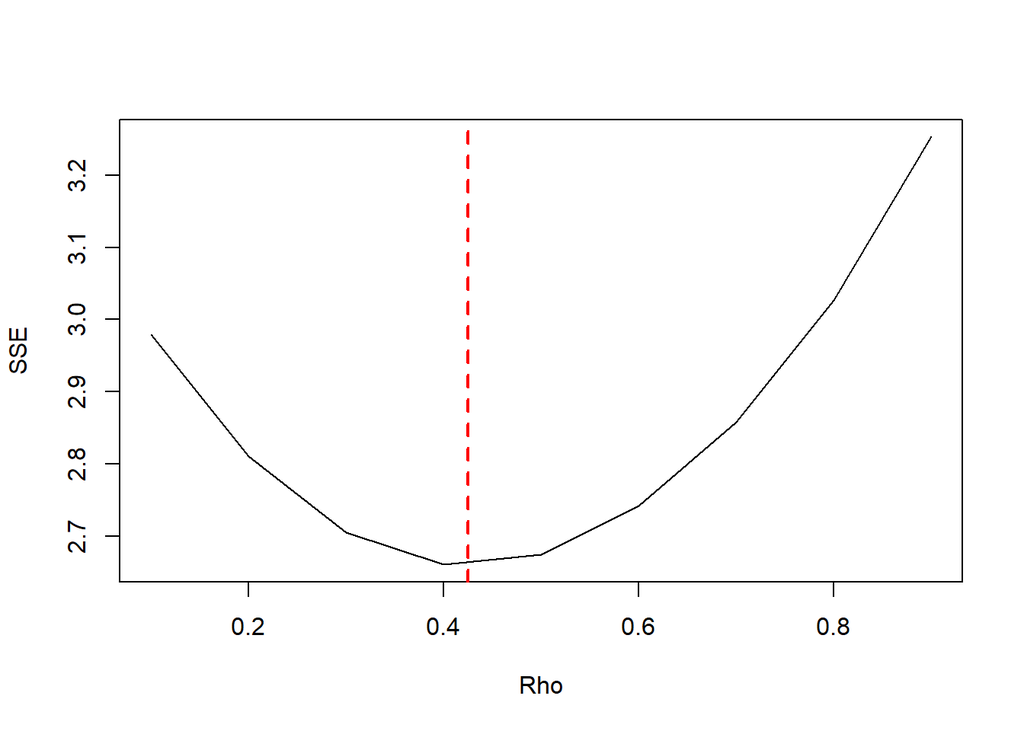

```r
#Grafik SSE optimum
par(mfrow = c(1,1))
plot(tab$SSE ~ tab$rho , type = "l", xlab = "Rho", ylab = "SSE")
abline(v = tabOpt[tabOpt$SSE==min(tabOpt$SSE),"rho"], lty = 2, col="red",lwd=2)
text(x=0.341, y=0.2397500, labels = "rho=0.341", cex = 0.8)
```

```r
#Model terbaik
modelHL <- hildreth.lu.func(0.341, model)
summary(modelHL)
```

```
##
## Call:
## lm(formula = y ~ x)
##
## Residuals:
##     Min      1Q  Median      3Q     Max
## -0.5870 -0.2606 -0.0515  0.2608  0.8285
##
## Coefficients:
##             Estimate Std. Error t value Pr(>|t|)
## (Intercept)  17.7307     0.9966   17.79 2.01e-12 ***
## x           -24.3027     1.7915  -13.57 1.51e-10 ***
## ---
## Signif. codes:  0 '***' 0.001 '**' 0.01 '*' 0.05 '.' 0.1 ' ' 1
##
## Residual standard error: 0.397 on 17 degrees of freedom
## Multiple R-squared:  0.9154, Adjusted R-squared:  0.9105
## F-statistic:   184 on 1 and 17 DF,  p-value: 1.509e-10
```

```r
#Transformasi Balik
cat("y = ", coef(modelHL)[1]/(1-0.341), "+", coef(modelHL)[2],"x", sep = "")
```

```
## y = 26.90551+-24.30265x
```

```r
#Deteksi autokorelasi
dwtest(modelHL)
```

```
##
##  Durbin-Watson test
##
## data:  modelHL
## DW = 1.8146, p-value = 0.2808
## alternative hypothesis: true autocorrelation is greater than 0
```

# Simpulan

1. Model regresi awal (OLS) market share terhadap price menghasilkan R² = 0.9511, namun uji Durbin-Watson menunjukkan adanya autokorelasi positif pada sisaan (DW = 1.1358 < dL = 1.20).
2. Penanganan dengan metode Cochrane-Orcutt berhasil menghilangkan autokorelasi pada sisaan, ditunjukkan oleh nilai DW baru sebesar 1.9580 yang sudah mendekati 2.
3. Model akhir yang direkomendasikan setelah penanganan autokorelasi adalah: Ŷt = 26.7221 − 24.0841 Xt, ρ̂ = 0.4252